# Titanic Machine Learning Case

This project is my version of machine learning applied to the famous Titanic Case.

Here, we have two data set (train and test) that represents information on passengers.

The train set contains an extra information : did the passenger survive or not, and the goal here is to find the patterns of survivors to predict whether a passenger from the test set will survive or not.

This is a Machine Learning project using supervised learning and more specifically classification.

## Get the data

```python
import pandas as pd
import numpy as np
from pandas.api.types import CategoricalDtype
import matplotlib.pyplot as plt
```

```python
#Get the data

train_set = pd.read_csv("train.csv")
test_set = pd.read_csv("test.csv")
```

```python
# Let's stack datasets together to apply modifications simultaneously

stacked = pd.concat([train_set, test_set])
stacked
```

|  | Age | Cabin | Embarked | Fare | Name | Parch | PassengerId | Pclass | Sex | SibSp | Survived | Ticket |
| --- | --- | --- | --- | --- | --- | --- | --- | --- | --- | --- | --- | --- |
| 0 | 22.0 | NaN | S | 7.2500 | Braund, Mr. Owen Harris | 0 | 1 | 3 | male | 1 | 0.0 | A/5 21171 |
| 1 | 38.0 | C85 | C | 71.2833 | Cumings, Mrs. John Bradley (Florence Briggs Th... | 0 | 2 | 1 | female | 1 | 1.0 | PC 17599 |
| 2 | 26.0 | NaN | S | 7.9250 | Heikkinen, Miss. Laina | 0 | 3 | 3 | female | 0 | 1.0 | STON/O2. 3101282 |
| 3 | 35.0 | C123 | S | 53.1000 | Futrelle, Mrs. Jacques Heath (Lily May Peel) | 0 | 4 | 1 | female | 1 | 1.0 | 113803 |
| 4 | 35.0 | NaN | S | 8.0500 | Allen, Mr. William Henry | 0 | 5 | 3 | male | 0 | 0.0 | 373450 |
| ... | ... | ... | ... | ... | ... | ... | ... | ... | ... | ... | ... | ... |
| 413 | NaN | NaN | S | 8.0500 | Spector, Mr. Woolf | 0 | 1305 | 3 | male | 0 | NaN | A.5. 3236 |
| 414 | 39.0 | C105 | C | 108.9000 | Oliva y Ocana, Dona. Fermina | 0 | 1306 | 1 | female | 0 | NaN | PC 17758 |
| 415 | 38.5 | NaN | S | 7.2500 | Saether, Mr. Simon Sivertsen | 0 | 1307 | 3 | male | 0 | NaN | SOTON/O.Q. 3101262 |
| 416 | NaN | NaN | S | 8.0500 | Ware, Mr. Frederick | 0 | 1308 | 3 | male | 0 | NaN | 359309 |
| 417 | NaN | NaN | C | 22.3583 | Peter, Master. Michael J | 1 | 1309 | 3 | male | 1 | NaN | 2668 |

1309 rows × 12 columns

## Data preparation and Features engineering

First impression, Sex and PClass seem to be determining factors for survival onboard.

```python
stacked[["Sex", "Survived"]].groupby(['Sex'], as_index=False).mean().sort_values(by='Survived', ascending=False)
```

|  | Sex | Survived |
| --- | --- | --- |
| 0 | female | 0.742038 |
| 1 | male | 0.188908 |

```python
stacked[['Pclass', 'Survived']].groupby(['Pclass'], as_index=False).mean().sort_values(by='Survived', ascending=False)
```

|  | Pclass | Survived |
| --- | --- | --- |
| 0 | 1 | 0.629630 |
| 1 | 2 | 0.472826 |
| 2 | 3 | 0.242363 |

This shows that upper class (in terms of boat's class) and women were more likely to survive.

This analysis help us to select this both features as important ones.

And now, we can transform Sex into a numerical value!

```python
#Sex
#Conditional function définition :

def s(stacked):
    if stacked['Sex'] == 'male':
        val = 1
    else:
        val = 0
    return val

#Modification of column 'Sex'
stacked['Sex'] = stacked.apply(s, axis=1)
stacked
```

|  | Age | Cabin | Embarked | Fare | Name | Parch | PassengerId | Pclass | Sex | SibSp | Survived | Ticket |
| --- | --- | --- | --- | --- | --- | --- | --- | --- | --- | --- | --- | --- |
| 0 | 22.0 | NaN | S | 7.2500 | Braund, Mr. Owen Harris | 0 | 1 | 3 | 1 | 1 | 0.0 | A/5 21171 |
| 1 | 38.0 | C85 | C | 71.2833 | Cumings, Mrs. John Bradley (Florence Briggs Th... | 0 | 2 | 1 | 0 | 1 | 1.0 | PC 17599 |
| 2 | 26.0 | NaN | S | 7.9250 | Heikkinen, Miss. Laina | 0 | 3 | 3 | 0 | 0 | 1.0 | STON/O2. 3101282 |
| 3 | 35.0 | C123 | S | 53.1000 | Futrelle, Mrs. Jacques Heath (Lily May Peel) | 0 | 4 | 1 | 0 | 1 | 1.0 | 113803 |
| 4 | 35.0 | NaN | S | 8.0500 | Allen, Mr. William Henry | 0 | 5 | 3 | 1 | 0 | 0.0 | 373450 |
| ... | ... | ... | ... | ... | ... | ... | ... | ... | ... | ... | ... | ... |
| 413 | NaN | NaN | S | 8.0500 | Spector, Mr. Woolf | 0 | 1305 | 3 | 1 | 0 | NaN | A.5. 3236 |
| 414 | 39.0 | C105 | C | 108.9000 | Oliva y Ocana, Dona. Fermina | 0 | 1306 | 1 | 0 | 0 | NaN | PC 17758 |
| 415 | 38.5 | NaN | S | 7.2500 | Saether, Mr. Simon Sivertsen | 0 | 1307 | 3 | 1 | 0 | NaN | SOTON/O.Q. 3101262 |
| 416 | NaN | NaN | S | 8.0500 | Ware, Mr. Frederick | 0 | 1308 | 3 | 1 | 0 | NaN | 359309 |
| 417 | NaN | NaN | C | 22.3583 | Peter, Master. Michael J | 1 | 1309 | 3 | 1 | 1 | NaN | 2668 |

1309 rows × 12 columns

However, for logical reason, we can remove the names: indeed, your name does not impact whether you will survive or not.

What can make the difference however is your title. It may be an element that can impact your survival in case of evacuation (because of hierarchy) Let's split names from their title

```python
#Get the title out of the name
split1 = stacked['Name'].str.split('.').str[0]
title = split1.str.split(' ').str[1]
title
```

```
0          Mr
1         Mrs
2        Miss
3         Mrs
4          Mr
        ...
413        Mr
414         y
415        Mr
416        Mr
417    Master
Name: Name, Length: 1309, dtype: object
```

```python
#Add the column to the dataset
stacked['Title'] = title
stacked = stacked.drop(['Name'], axis=1)
stacked
```

|  | Age | Cabin | Embarked | Fare | Parch | PassengerId | Pclass | Sex | SibSp | Survived | Ticket | Title |
| --- | --- | --- | --- | --- | --- | --- | --- | --- | --- | --- | --- | --- |
| 0 | 22.0 | NaN | S | 7.2500 | 0 | 1 | 3 | 1 | 1 | 0.0 | A/5 21171 | Mr |
| 1 | 38.0 | C85 | C | 71.2833 | 0 | 2 | 1 | 0 | 1 | 1.0 | PC 17599 | Mrs |
| 2 | 26.0 | NaN | S | 7.9250 | 0 | 3 | 3 | 0 | 0 | 1.0 | STON/O2. 3101282 | Miss |
| 3 | 35.0 | C123 | S | 53.1000 | 0 | 4 | 1 | 0 | 1 | 1.0 | 113803 | Mrs |
| 4 | 35.0 | NaN | S | 8.0500 | 0 | 5 | 3 | 1 | 0 | 0.0 | 373450 | Mr |
| ... | ... | ... | ... | ... | ... | ... | ... | ... | ... | ... | ... | ... |
| 413 | NaN | NaN | S | 8.0500 | 0 | 1305 | 3 | 1 | 0 | NaN | A.5. 3236 | Mr |
| 414 | 39.0 | C105 | C | 108.9000 | 0 | 1306 | 1 | 0 | 0 | NaN | PC 17758 | y |
| 415 | 38.5 | NaN | S | 7.2500 | 0 | 1307 | 3 | 1 | 0 | NaN | SOTON/O.Q. 3101262 | Mr |
| 416 | NaN | NaN | S | 8.0500 | 0 | 1308 | 3 | 1 | 0 | NaN | 359309 | Mr |
| 417 | NaN | NaN | C | 22.3583 | 1 | 1309 | 3 | 1 | 1 | NaN | 2668 | Master |

1309 rows × 12 columns

Let's change it to numerical values:

```python
stacked['Title'].nunique()
```

```
34
```

There are 34 different titles

```python
#we create a second dataframe with title list and we attribute one number (index) to each title
t = stacked['Title'].unique()
df = pd.DataFrame(t, columns=['Title'])
df['index'] = df.index
df.head()
```

|  | Title | index |
| --- | --- | --- |
| 0 | Mr | 0 |
| 1 | Mrs | 1 |
| 2 | Miss | 2 |
| 3 | Master | 3 |
| 4 | Planke, | 4 |

```python
#merge df with stacked
stacked= pd.merge(stacked, df[['Title', 'index']],left_on = 'Title', right_on = 'Title', how = 'left')
#delete title and rename index
stacked = stacked.drop('Title', axis=1)
stacked = stacked.rename(columns={'index':'Title'})
stacked
```

|  | Age | Cabin | Embarked | Fare | Parch | PassengerId | Pclass | Sex | SibSp | Survived | Ticket | Title |
| --- | --- | --- | --- | --- | --- | --- | --- | --- | --- | --- | --- | --- |
| 0 | 22.0 | NaN | S | 7.2500 | 0 | 1 | 3 | 1 | 1 | 0.0 | A/5 21171 | 0 |
| 1 | 38.0 | C85 | C | 71.2833 | 0 | 2 | 1 | 0 | 1 | 1.0 | PC 17599 | 1 |
| 2 | 26.0 | NaN | S | 7.9250 | 0 | 3 | 3 | 0 | 0 | 1.0 | STON/O2. 3101282 | 2 |
| 3 | 35.0 | C123 | S | 53.1000 | 0 | 4 | 1 | 0 | 1 | 1.0 | 113803 | 1 |
| 4 | 35.0 | NaN | S | 8.0500 | 0 | 5 | 3 | 1 | 0 | 0.0 | 373450 | 0 |
| ... | ... | ... | ... | ... | ... | ... | ... | ... | ... | ... | ... | ... |
| 1304 | NaN | NaN | S | 8.0500 | 0 | 1305 | 3 | 1 | 0 | NaN | A.5. 3236 | 0 |
| 1305 | 39.0 | C105 | C | 108.9000 | 0 | 1306 | 1 | 0 | 0 | NaN | PC 17758 | 13 |
| 1306 | 38.5 | NaN | S | 7.2500 | 0 | 1307 | 3 | 1 | 0 | NaN | SOTON/O.Q. 3101262 | 0 |
| 1307 | NaN | NaN | S | 8.0500 | 0 | 1308 | 3 | 1 | 0 | NaN | 359309 | 0 |
| 1308 | NaN | NaN | C | 22.3583 | 1 | 1309 | 3 | 1 | 1 | NaN | 2668 | 3 |

1309 rows × 12 columns

If we check our data we will see that some columns have missing values:

```python
#Check for missing values
print(stacked.isnull().sum().sort_values(ascending=False))
```

```
Cabin          1014
Survived        418
Age             263
Embarked          2
Fare              1
Title             0
Ticket            0
SibSp             0
Sex               0
Pclass            0
PassengerId       0
Parch             0
dtype: int64
```

We can see that 'Age', 'Cabin', 'Embarked', 'Fare' and 'Survived have missing value.

AGE: with almost 300 missing values, it could be interesting to fill it with value such as average or median which won't mess up our analysis

CABIN: They are too many missing values on Cabin. Therefore, we will just drop the column

SURVIVED: These missing values correspond to the test dataset. Indeed, since we are looking to predict the survival of this persenger, they don't have any value yet.

```python
#Age description
stacked['Age'].describe()
```

```
count    1046.000000
mean       29.881138
std        14.413493
min         0.170000
25%        21.000000
50%        28.000000
75%        39.000000
max        80.000000
Name: Age, dtype: float64
```

AGE: Here, we can see that average us almost 30 and median is 28. Since we have extrem value (80) and a big difference between the third quartile and the max value, we will choose to use the median to fill missing rows.

```python
#Replace NaN in age by median
median = stacked['Age'].median()
r = stacked['Age'].fillna(median, inplace=True)
```

Here, we will use a bit of data vizualisation to understand the impact of age and sex on survival

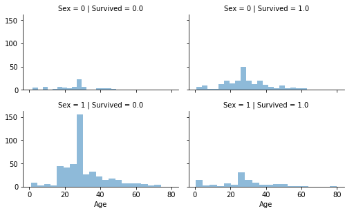

```python
#Visualization with seaborn
import seaborn as sns

grid = sns.FacetGrid(stacked, col='Survived', row ='Sex', size=2.2, aspect=1.6)
grid.map(plt.hist, 'Age', alpha=.5, bins=20)
grid.add_legend();
```

As we can see, age can be considered using ranges : Let's create those ranges.

```python
#Range of age
stacked['AgeRange'] = pd.cut(stacked['Age'], 5)
ar = stacked[['AgeRange', 'Survived']].groupby(['AgeRange'], as_index=False).mean().sort_values(by='AgeRange', ascending=True)
ar
```

|  | AgeRange | Survived |
| --- | --- | --- |
| 0 | (0.0902, 16.136] | 0.550000 |
| 1 | (16.136, 32.102] | 0.344168 |
| 2 | (32.102, 48.068] | 0.404255 |
| 3 | (48.068, 64.034] | 0.434783 |
| 4 | (64.034, 80.0] | 0.090909 |

```python
# transform range into numerical values
ar['index']= ar.index
stacked = pd.merge(stacked, ar[['AgeRange', 'index']],left_on = 'AgeRange', right_on = 'AgeRange', how = 'left')
stacked = stacked.drop('AgeRange', axis=1)
stacked = stacked.drop('Age', axis=1)
stacked = stacked.rename(columns={'index':'Age'})
stacked.head()
```

|  | Cabin | Embarked | Fare | Parch | PassengerId | Pclass | Sex | SibSp | Survived | Ticket | Title | Age |
| --- | --- | --- | --- | --- | --- | --- | --- | --- | --- | --- | --- | --- |
| 0 | NaN | S | 7.2500 | 0 | 1 | 3 | 1 | 1 | 0.0 | A/5 21171 | 0 | 1 |
| 1 | C85 | C | 71.2833 | 0 | 2 | 1 | 0 | 1 | 1.0 | PC 17599 | 1 | 2 |
| 2 | NaN | S | 7.9250 | 0 | 3 | 3 | 0 | 0 | 1.0 | STON/O2. 3101282 | 2 | 1 |
| 3 | C123 | S | 53.1000 | 0 | 4 | 1 | 0 | 1 | 1.0 | 113803 | 1 | 2 |
| 4 | NaN | S | 8.0500 | 0 | 5 | 3 | 1 | 0 | 0.0 | 373450 | 0 | 2 |

```python
#Drop Cabin
stacked = stacked.drop('Cabin', axis = 1)
```

Now, we can do the same with Embarked

```python
#Extract most common value
d = stacked.groupby('Embarked')['PassengerId'].count().sort_values(ascending = False).idxmax()
d
```

```
'S'
```

S is the most common value

```python
# Fillna with the most common value of Embarked

stacked['Embarked'] = stacked['Embarked'].fillna(d)

#Change Embarked into numerical values
e = stacked['Embarked'].unique()
dfa = pd.DataFrame(e, columns=['Embarked'])
dfa['index'] = dfa.index
stacked = pd.merge(stacked, dfa[['Embarked', 'index']],left_on = 'Embarked', right_on = 'Embarked', how = 'left')
stacked = stacked.drop('Embarked', axis=1)
stacked = stacked.rename(columns={'index':'Embarked'})
stacked.head(5)
```

|  | Fare | Parch | PassengerId | Pclass | Sex | SibSp | Survived | Ticket | Title | Age | Embarked |
| --- | --- | --- | --- | --- | --- | --- | --- | --- | --- | --- | --- |
| 0 | 7.2500 | 0 | 1 | 3 | 1 | 1 | 0.0 | A/5 21171 | 0 | 1 | 0 |
| 1 | 71.2833 | 0 | 2 | 1 | 0 | 1 | 1.0 | PC 17599 | 1 | 2 | 1 |
| 2 | 7.9250 | 0 | 3 | 3 | 0 | 0 | 1.0 | STON/O2. 3101282 | 2 | 1 | 0 |
| 3 | 53.1000 | 0 | 4 | 1 | 0 | 1 | 1.0 | 113803 | 1 | 2 | 0 |
| 4 | 8.0500 | 0 | 5 | 3 | 1 | 0 | 0.0 | 373450 | 0 | 2 | 0 |

```python
#Idem for Fare
most_common_val = stacked.groupby('Fare')['PassengerId'].count().sort_values(ascending = False).idxmax()

stacked['Fare'] = stacked['Fare'].fillna(most_common_val)
```

Ticket has 929 different type of ticket. We can therefore say that this feature is going to be useless: to many different types compare to the number of passenger.

```python
stacked['Ticket'].nunique()
```

```
929
```

```python
#Drop Cabin
stacked = stacked.drop('Ticket', axis =1)
```

Now, we are going to flag whether a person is alone or not

```python
# Intermediate column: Family_count
stacked['Family_count'] = stacked['SibSp']+stacked['Parch']
stacked['Family_count'].head()
```

```
0    1
1    1
2    0
3    1
4    0
Name: Family_count, dtype: int64
```

```python
#Conditional function définition :

def f(stacked):
    if stacked['Family_count'] < 1:
        val = 1
    else:
        val = 0
    return val
```

```python
#Creation of column 'IsAlone'
stacked['IsAlone'] = stacked.apply(f, axis=1)
stacked[['IsAlone', 'Survived']].groupby(['IsAlone'], as_index=False).mean()
```

|  | IsAlone | Survived |
| --- | --- | --- |
| 0 | 0 | 0.505650 |
| 1 | 1 | 0.303538 |

This information is relevant, we can now drop the following columns : SibSp, Family_count and Parch

```python
#Drop SibSp, Family_count and Parch
stacked = stacked.drop('Parch', axis = 1)
stacked = stacked.drop('SibSp', axis = 1)
stacked = stacked.drop('Family_count', axis = 1)
```

```python
stacked.head()
```

|  | Fare | PassengerId | Pclass | Sex | Survived | Title | Age | Embarked | IsAlone |
| --- | --- | --- | --- | --- | --- | --- | --- | --- | --- |
| 0 | 7.2500 | 1 | 3 | 1 | 0.0 | 0 | 1 | 0 | 0 |
| 1 | 71.2833 | 2 | 1 | 0 | 1.0 | 1 | 2 | 1 | 0 |
| 2 | 7.9250 | 3 | 3 | 0 | 1.0 | 2 | 1 | 0 | 1 |
| 3 | 53.1000 | 4 | 1 | 0 | 1.0 | 1 | 2 | 0 | 0 |
| 4 | 8.0500 | 5 | 3 | 1 | 0.0 | 0 | 2 | 0 | 1 |

Now that our Data is ready, we can re-split it into train and test set :) !

## Splitting data

```python
#historical is the share of the data that contains 'Survived' columns
historical = stacked.loc[stacked['Survived'].notnull()]
historical
```

|  | Fare | PassengerId | Pclass | Sex | Survived | Title | Age | Embarked | IsAlone |
| --- | --- | --- | --- | --- | --- | --- | --- | --- | --- |
| 0 | 7.2500 | 1 | 3 | 1 | 0.0 | 0 | 1 | 0 | 0 |
| 1 | 71.2833 | 2 | 1 | 0 | 1.0 | 1 | 2 | 1 | 0 |
| 2 | 7.9250 | 3 | 3 | 0 | 1.0 | 2 | 1 | 0 | 1 |
| 3 | 53.1000 | 4 | 1 | 0 | 1.0 | 1 | 2 | 0 | 0 |
| 4 | 8.0500 | 5 | 3 | 1 | 0.0 | 0 | 2 | 0 | 1 |
| ... | ... | ... | ... | ... | ... | ... | ... | ... | ... |
| 886 | 13.0000 | 887 | 2 | 1 | 0.0 | 6 | 1 | 0 | 1 |
| 887 | 30.0000 | 888 | 1 | 0 | 1.0 | 2 | 1 | 0 | 1 |
| 888 | 23.4500 | 889 | 3 | 0 | 0.0 | 2 | 1 | 0 | 0 |
| 889 | 30.0000 | 890 | 1 | 1 | 1.0 | 0 | 1 | 1 | 1 |
| 890 | 7.7500 | 891 | 3 | 1 | 0.0 | 0 | 1 | 2 | 1 |

891 rows × 9 columns

```python
#Do not contain 'survived'
topredict_set = stacked.loc[stacked['Survived'].isnull()]
topredict_set = topredict_set.drop('Survived', axis = 1)
topredict_set
```

|  | Fare | PassengerId | Pclass | Sex | Title | Age | Embarked | IsAlone |
| --- | --- | --- | --- | --- | --- | --- | --- | --- |
| 891 | 7.8292 | 892 | 3 | 1 | 0 | 2 | 2 | 1 |
| 892 | 7.0000 | 893 | 3 | 0 | 1 | 2 | 0 | 0 |
| 893 | 9.6875 | 894 | 2 | 1 | 0 | 3 | 2 | 1 |
| 894 | 8.6625 | 895 | 3 | 1 | 0 | 1 | 0 | 1 |
| 895 | 12.2875 | 896 | 3 | 0 | 1 | 1 | 0 | 0 |
| ... | ... | ... | ... | ... | ... | ... | ... | ... |
| 1304 | 8.0500 | 1305 | 3 | 1 | 0 | 1 | 0 | 1 |
| 1305 | 108.9000 | 1306 | 1 | 0 | 13 | 2 | 1 | 1 |
| 1306 | 7.2500 | 1307 | 3 | 1 | 0 | 2 | 0 | 1 |
| 1307 | 8.0500 | 1308 | 3 | 1 | 0 | 1 | 0 | 1 |
| 1308 | 22.3583 | 1309 | 3 | 1 | 3 | 1 | 1 | 0 |

418 rows × 8 columns

Now, let's create a test set for cross validation.

```python
#create the test set:
def split_train_test(data, test_ratio):
    np.random.seed(42) #always generate the same random data
    shuffled_indices = np.random.permutation(len(data))
    test_set_size = int(len(data) * test_ratio)
    test_indices = shuffled_indices[:test_set_size]
    train_indices = shuffled_indices[test_set_size:]
    return data.iloc[train_indices], data.iloc[test_indices]


train_set, test_set = split_train_test(historical, 0.20)
```

```python
#Defining X_train and Y_train
X_train = train_set.drop('Survived', axis=1)
Y_train = train_set['Survived']
```

## Let's start playing with classifiers

```python
#we define display_scores to display different scores that will allow us to select the best model
def display_scores(scores):
    print('Scores:', scores)
    print('Mean', scores.mean())
    print('Standard deviation', scores.std())
```

### Random Forest Classifier

```python
from sklearn.ensemble import RandomForestClassifier
RFC = RandomForestClassifier(n_estimators=1000)
```

```python
RFC.fit(X_train, Y_train)
predicted_Y_train = RFC.predict(X_train)

from sklearn.model_selection import cross_val_score #return the validation
RFC_scores = cross_val_score(RFC, X_train, Y_train, cv=10, scoring ='accuracy')

display_scores(RFC_scores) #50% of the total are true
print("\n")

from sklearn.model_selection import cross_val_predict #return the prediciton
RFC_train_Y_pred= cross_val_predict(RFC, X_train, Y_train, cv=3)

from sklearn.metrics import precision_score, recall_score
RFC_precision= precision_score(Y_train, RFC_train_Y_pred)
RFC_recall= recall_score(Y_train, RFC_train_Y_pred)
print('Precision is:', RFC_precision, 'and Recall is:', RFC_recall)
```

```
Scores: [0.83333333 0.76388889 0.77777778 0.86111111 0.83098592 0.76056338
 0.8028169  0.78873239 0.76056338 0.91428571]
Mean 0.8094058797227811
Standard deviation 0.04798494769564089


Precision is: 0.7922077922077922 and Recall is: 0.6802973977695167
```

### SGD classifier

```python
from sklearn.linear_model import SGDClassifier
SGD = SGDClassifier(random_state = 42)
```

```python
SGD.fit(X_train, Y_train)
predicted_Y_train = SGD.predict(X_train)

from sklearn.model_selection import cross_val_score #return the validation
SGD_scores = cross_val_score(SGD, X_train, Y_train, cv=10, scoring ='accuracy')

display_scores(SGD_scores) #50% of the total are true
print("\n")

from sklearn.model_selection import cross_val_predict #return the prediciton
SGD_train_Y_pred= cross_val_predict(SGD, X_train, Y_train, cv=3)

from sklearn.metrics import precision_score, recall_score
SGD_precision= precision_score(Y_train, SGD_train_Y_pred)
SGD_recall= recall_score(Y_train, SGD_train_Y_pred)
print('Precision is:', SGD_precision, 'and Recall is:', SGD_recall)
```

```
Scores: [0.66666667 0.68055556 0.65277778 0.72222222 0.61971831 0.63380282
 0.63380282 0.64788732 0.63380282 0.37142857]
Mean 0.6262664878157838
Standard deviation 0.08950582124891168


Precision is: 0.4375 and Recall is: 0.6245353159851301
```

### Logistic Regression

```python
from sklearn.linear_model import LogisticRegression
LR = LogisticRegression(random_state = 42)


from warnings import simplefilter #every iteration with logreg output an annoying future warning
simplefilter(action = 'ignore', category = FutureWarning)
```

```python
LR.fit(X_train, Y_train)
predicted_Y_train = LR.predict(X_train)

from sklearn.model_selection import cross_val_score #return the validation
LR_scores = cross_val_score(LR, X_train, Y_train, cv=10, scoring ='accuracy')

display_scores(LR_scores) #50% of the total are true
print("\n")

from sklearn.model_selection import cross_val_predict #return the prediciton
LR_train_Y_pred= cross_val_predict(LR, X_train, Y_train, cv=3)

from sklearn.metrics import precision_score, recall_score
LR_precision= precision_score(Y_train, LR_train_Y_pred)
LR_recall= recall_score(Y_train, LR_train_Y_pred)
print('Precision is:', LR_precision, 'and Recall is:', LR_recall)
```

```
Scores: [0.79166667 0.76388889 0.70833333 0.90277778 0.8028169  0.70422535
 0.70422535 0.74647887 0.77464789 0.91428571]
Mean 0.7813346747149564
Standard deviation 0.0719566042132041


Precision is: 0.724 and Recall is: 0.6728624535315985
```

### K Neighbors Classifier

```python
from sklearn.neighbors import KNeighborsClassifier
from sklearn import preprocessing #eventually to scale X
KN = KNeighborsClassifier()
```

```python
KN.fit(X_train, Y_train)
predicted_Y_train = KN.predict(X_train)

from sklearn.model_selection import cross_val_score #return the validation
KN_scores = cross_val_score(KN, X_train, Y_train, cv=10, scoring ='accuracy')

display_scores(KN_scores) #50% of the total are true
print("\n")

from sklearn.model_selection import cross_val_predict #return the prediciton
KN_train_Y_pred= cross_val_predict(KN, X_train, Y_train, cv=3)

from sklearn.metrics import precision_score, recall_score
KN_precision= precision_score(Y_train, KN_train_Y_pred)
KN_recall= recall_score(Y_train, KN_train_Y_pred)
print('Precision is:', KN_precision, 'and Recall is:', KN_recall)
```

```
Scores: [0.65277778 0.70833333 0.56944444 0.69444444 0.57746479 0.6056338
 0.6056338  0.61971831 0.56338028 0.65714286]
Mean 0.625397384305835
Standard deviation 0.048467685683036686


Precision is: 0.5022421524663677 and Recall is: 0.4163568773234201
```

### Decision Tree Classifier

```python
from sklearn import tree
DT = tree.DecisionTreeClassifier()
```

```python
DT.fit(X_train, Y_train)
predicted_Y_train = DT.predict(X_train)

from sklearn.model_selection import cross_val_score #return the validation
DT_scores = cross_val_score(DT, X_train, Y_train, cv=10, scoring ='accuracy')

display_scores(DT_scores) #50% of the total are true
print("\n")

from sklearn.model_selection import cross_val_predict #return the prediciton
DT_train_Y_pred= cross_val_predict(DT, X_train, Y_train, cv=3)

from sklearn.metrics import precision_score, recall_score
DT_precision= precision_score(Y_train, DT_train_Y_pred)
DT_recall= recall_score(Y_train, DT_train_Y_pred)
print('Precision is:', DT_precision, 'and Recall is:', DT_recall)
```

```
Scores: [0.72222222 0.58333333 0.70833333 0.77777778 0.74647887 0.71830986
 0.74647887 0.67605634 0.77464789 0.82857143]
Mean 0.7282209926224011
Standard deviation 0.06292182587870337


Precision is: 0.6498194945848376 and Recall is: 0.6691449814126395
```

### Bernoulli Naive Bayes Classifier

```python
from sklearn.naive_bayes import BernoulliNB
from sklearn.naive_bayes import MultinomialNB

BNB = BernoulliNB(binarize = True) #function will binarize data
```

```python
BNB.fit(X_train, Y_train)
predicted_Y_train = BNB.predict(X_train)

from sklearn.model_selection import cross_val_score #return the validation
BNB_scores = cross_val_score(BNB, X_train, Y_train, cv=10, scoring ='accuracy')

display_scores(BNB_scores) #50% of the total are true
print("\n")

from sklearn.model_selection import cross_val_predict #return the prediciton
BNB_train_Y_pred= cross_val_predict(BNB, X_train, Y_train, cv=3)

from sklearn.metrics import precision_score, recall_score
BNB_precision= precision_score(Y_train, BNB_train_Y_pred)
BNB_recall= recall_score(Y_train, BNB_train_Y_pred)
print('Precision is:', BNB_precision, 'and Recall is:', BNB_recall)
```

```
Scores: [0.625      0.66666667 0.59722222 0.65277778 0.67605634 0.56338028
 0.6056338  0.64788732 0.57746479 0.68571429]
Mean 0.629780348759222
Standard deviation 0.040372320930531114


Precision is: 0.5815217391304348 and Recall is: 0.39776951672862454
```

### Gaussian Naive Bayes Classifier

```python
from sklearn.naive_bayes import GaussianNB
GNB = GaussianNB()
```

```python
GNB.fit(X_train, Y_train)
predicted_Y_train = GNB.predict(X_train)

from sklearn.model_selection import cross_val_score #return the validation
GNB_scores = cross_val_score(GNB, X_train, Y_train, cv=10, scoring ='accuracy')

display_scores(GNB_scores) #50% of the total are true
print("\n")

from sklearn.model_selection import cross_val_predict #return the prediciton
GNB_train_Y_pred= cross_val_predict(GNB, X_train, Y_train, cv=3)

from sklearn.metrics import precision_score, recall_score
GNB_precision= precision_score(Y_train, GNB_train_Y_pred)
GNB_recall= recall_score(Y_train, GNB_train_Y_pred)
print('Precision is:', GNB_precision, 'and Recall is:', GNB_recall)
```

```
Scores: [0.76388889 0.77777778 0.70833333 0.93055556 0.78873239 0.67605634
 0.69014085 0.71830986 0.70422535 0.87142857]
Mean 0.7629448915716521
Standard deviation 0.078753213947817


Precision is: 0.7211155378486056 and Recall is: 0.6728624535315985
```

### Linear Discriminant Analysis

```python
from sklearn.discriminant_analysis import LinearDiscriminantAnalysis
LDA = LinearDiscriminantAnalysis()
```

```python
LDA.fit(X_train, Y_train)
predicted_Y_train = LDA.predict(X_train)

from sklearn.model_selection import cross_val_score #return the validation
LDA_scores = cross_val_score(LDA, X_train, Y_train, cv=10, scoring ='accuracy')

display_scores(LDA_scores) #50% of the total are true
print("\n")

from sklearn.model_selection import cross_val_predict #return the prediciton
LDA_train_Y_pred= cross_val_predict(LDA, X_train, Y_train, cv=3)

from sklearn.metrics import precision_score, recall_score
LDA_precision= precision_score(Y_train, LDA_train_Y_pred)
LDA_recall= recall_score(Y_train, LDA_train_Y_pred)
print('Precision is:', LDA_precision, 'and Recall is:', LDA_recall)
```

```
Scores: [0.81944444 0.75       0.69444444 0.91666667 0.81690141 0.67605634
 0.73239437 0.78873239 0.77464789 0.9       ]
Mean 0.7869287949921754
Standard deviation 0.07543905358783627


Precision is: 0.7346938775510204 and Recall is: 0.6691449814126395
```

```python
#We create a matrix to compare results
MCA = {'accuracy': [np.mean(RFC_scores), np.mean(SGD_scores), np.mean(LR_scores), np.mean(KN_scores), np.mean(DT_scores), np.mean(BNB_scores), np.mean(GNB_scores), np.mean(LDA_scores) ],
     'precision': [np.mean(SGD_precision), np.mean(LR_precision), np.mean(KN_precision), np.mean(DT_precision), np.mean(BNB_precision), np.mean(GNB_precision), np.mean(RFC_precision), np.mean(LDA_precision) ],
    'Index' :['RFC','SGD','LR','KN','DT','BNB','GNB','LDA']
    }
accuracy_matrix = pd.DataFrame(MCA)
accuracy_matrix = accuracy_matrix.set_index('Index')
print(accuracy_matrix.sort_values('accuracy', ascending = False))
```

```
       accuracy  precision
Index
RFC    0.809406   0.437500
LDA    0.786929   0.734694
LR     0.781335   0.502242
GNB    0.762945   0.792208
DT     0.728221   0.581522
BNB    0.629780   0.721116
SGD    0.626266   0.724000
KN     0.625397   0.649819
```

Here, we decide to keep the top 3: RFC, LR, LDA

and we will now try to find the best parameters for these models !

## Hypertuning

### RFC tuned

```python
#Hypertuning using RandomizedSearchCV

from sklearn.model_selection import RandomizedSearchCV

param_grid = {

'n_estimators': [150, 200, 400, 700, 1000],

'max_features': ['auto', 'sqrt', 'log2'],

'criterion': ['entropy', 'gini'],

'max_depth': [5, 50, 150],

'min_samples_leaf': [2, 10, 50]}

random = RandomizedSearchCV(estimator = RFC, param_distributions = param_grid, cv = 3, n_jobs=-1)

random_result = random.fit(X_train, Y_train)

# Summarize results

print("Best: %f using %s" % (random_result.best_score_, random_result.best_params_))
```

```
Best: 0.823282 using {'n_estimators': 400, 'min_samples_leaf': 2, 'max_features': 'sqrt', 'max_depth': 50, 'criterion': 'entropy'}
```

```python
RFC = RandomForestClassifier(**random_result.best_params_)

RFC.fit(X_train, Y_train)

from sklearn.model_selection import cross_val_score

RFC_scores_tuned = cross_val_score(RFC, X_train, Y_train, cv=15, scoring ='accuracy')

display_scores(RFC_scores_tuned)

print('/n')

from sklearn.model_selection import cross_val_predict #return the prediciton

RFC_train_Y_pred_tuned = cross_val_predict(RFC, X_train, Y_train, cv=3)

from sklearn.metrics import precision_score, recall_score

RFC_precision_tuned = precision_score(Y_train, RFC_train_Y_pred_tuned)

RFC_recall_tuned = recall_score(Y_train, RFC_train_Y_pred_tuned)

print('Precision is:', RFC_precision_tuned, 'and Recall is:', RFC_recall_tuned)
```

```
Scores: [0.79166667 0.83333333 0.72916667 0.75       0.875      0.875
 0.85416667 0.83333333 0.77083333 0.74468085 0.80851064 0.76595745
 0.72340426 0.87234043 0.91304348]
Mean 0.8093624730188096
Standard deviation 0.0587079320945668
/n
Precision is: 0.8287037037037037 and Recall is: 0.6654275092936803
```

### LR tuned

```python
from sklearn.model_selection import GridSearchCV
```

```python
LogReg = LogisticRegression()

param_grid = [{'penalty' : ['l2', 'none'], 'solver' : ['newton-cg', 'lbfgs', 'sag', 'saga']}]
grid_search = GridSearchCV(LogReg, param_grid, cv=5, scoring='accuracy')



grid_search.fit(X_train, Y_train)
print(grid_search.best_params_)
```

[output not shown]

```
{'penalty': 'l2', 'solver': 'lbfgs'}
```

```python
LR = LogisticRegression(**grid_search.best_params_)

LR.fit(X_train, Y_train)

from sklearn.model_selection import cross_val_score
LR_scores_tuned = cross_val_score(LR, X_train, Y_train, cv=10, scoring ='accuracy')

display_scores(LR_scores_tuned)

print('\n')


from sklearn.model_selection import cross_val_predict #return the prediciton
LR_train_Y_pred_tuned = cross_val_predict(LR, X_train, Y_train, cv=3)

from sklearn.metrics import precision_score, recall_score
LR_precision_tuned = precision_score(Y_train, LR_train_Y_pred_tuned)
LR_recall_tuned = recall_score(Y_train, LR_train_Y_pred_tuned)
print('Precision is:', LR_precision_tuned, 'and Recall is:', LR_recall_tuned)
```

```
Scores: [0.77777778 0.76388889 0.69444444 0.93055556 0.8028169  0.70422535
 0.67605634 0.74647887 0.76056338 0.88571429]
Mean 0.7742521797451374
Standard deviation 0.07724280654985156


Precision is: 0.7295081967213115 and Recall is: 0.6617100371747212
```

### LDA tuned

```python
LDA = LinearDiscriminantAnalysis()

param_grid = [{'solver' : ['svd', 'lsqr'], 'n_components' : [None, 2, 5, 10, 15]}]
grid_search = GridSearchCV(LDA, param_grid, cv=5, scoring='accuracy')



grid_search.fit(X_train, Y_train)
print(grid_search.best_params_)
```

[output not shown]

```
{'n_components': None, 'solver': 'svd'}
```

[output not shown]

```python
LDA = LinearDiscriminantAnalysis(**grid_search.best_params_)

LDA.fit(X_train, Y_train)

from sklearn.model_selection import cross_val_score
LDA_scores_tuned = cross_val_score(LDA, X_train, Y_train, cv=10, scoring ='accuracy')

display_scores(LDA_scores_tuned)

print('\n')


from sklearn.model_selection import cross_val_predict #return the prediciton
LDA_train_Y_pred_tuned = cross_val_predict(LDA, X_train, Y_train, cv=3)

from sklearn.metrics import precision_score, recall_score
LDA_precision_tuned = precision_score(Y_train, LDA_train_Y_pred_tuned)
LDA_recall_tuned = recall_score(Y_train, LDA_train_Y_pred_tuned)
print('Precision is:', LDA_precision_tuned, 'and Recall is:', LDA_recall_tuned)
```

```
Scores: [0.81944444 0.75       0.69444444 0.91666667 0.81690141 0.67605634
 0.73239437 0.78873239 0.77464789 0.9       ]
Mean 0.7869287949921754
Standard deviation 0.07543905358783627


Precision is: 0.7346938775510204 and Recall is: 0.6691449814126395
```

```python
#We create a matrix to compare results
MCA2 = {'accuracy': [np.mean(RFC_scores_tuned), np.mean(LR_scores_tuned), np.mean(LDA_scores_tuned)],
     'precision': [np.mean(RFC_precision_tuned), np.mean(LR_precision_tuned), np.mean(LDA_precision_tuned)],
    'Index' :['RFC','LR','LDA']
    }
accuracy_matrix = pd.DataFrame(MCA2)
accuracy_matrix = accuracy_matrix.set_index('Index')
print(accuracy_matrix.sort_values('accuracy', ascending = False))
```

```
       accuracy  precision
Index
RFC    0.809362   0.828704
LDA    0.786929   0.734694
LR     0.774252   0.729508
```

Here we can see that RFC is our best model so far.

This result are not perfect, however they are the best that I've got even after editing my features and hypertuning. Besides, this my first machine learning project. Therefore, I am going to stick to these results.

## Preparing the test_set

```python
X_test = test_set.drop('Survived', axis=1)
Y_test = test_set['Survived']
```

```python
from sklearn.metrics import accuracy_score
from sklearn.metrics import precision_score
```

```python
#Applying RFC to test_set
RFC = RandomForestClassifier(**random_result.best_params_)

RFC.fit(X_train, Y_train)
RFC.predict(X_test)

#from sklearn.model_selection import cross_val_score
#RFC_scores_MF_predicted_test = cross_val_score(RFC, X_train_Sale_MF, test_set_num['Sale_MF'], cv=15, scoring ='accuracy')


accuracy_test = accuracy_score(Y_test, RFC.predict(X_test))

precision_test = precision_score(Y_test, RFC.predict(X_test))

print('Accuracy :', accuracy_test)
print('Precision :', precision_test)
```

```
Accuracy : 0.8314606741573034
Precision : 0.8028169014084507
```

Our result are similar with both train and test set. We can therefore move on to prediction

## Prediction

```python
RFC = RandomForestClassifier(**random_result.best_params_)

RFC.fit(X_train, Y_train)
prediction = RFC.predict(topredict_set)
topredict_set['prediction'] = prediction
topredict_set
```

|  | Fare | PassengerId | Pclass | Sex | Title | Age | Embarked | IsAlone | prediction |
| --- | --- | --- | --- | --- | --- | --- | --- | --- | --- |
| 891 | 7.8292 | 892 | 3 | 1 | 0 | 2 | 2 | 1 | 0.0 |
| 892 | 7.0000 | 893 | 3 | 0 | 1 | 2 | 0 | 0 | 0.0 |
| 893 | 9.6875 | 894 | 2 | 1 | 0 | 3 | 2 | 1 | 0.0 |
| 894 | 8.6625 | 895 | 3 | 1 | 0 | 1 | 0 | 1 | 0.0 |
| 895 | 12.2875 | 896 | 3 | 0 | 1 | 1 | 0 | 0 | 1.0 |
| ... | ... | ... | ... | ... | ... | ... | ... | ... | ... |
| 1304 | 8.0500 | 1305 | 3 | 1 | 0 | 1 | 0 | 1 | 0.0 |
| 1305 | 108.9000 | 1306 | 1 | 0 | 13 | 2 | 1 | 1 | 1.0 |
| 1306 | 7.2500 | 1307 | 3 | 1 | 0 | 2 | 0 | 1 | 0.0 |
| 1307 | 8.0500 | 1308 | 3 | 1 | 0 | 1 | 0 | 1 | 0.0 |
| 1308 | 22.3583 | 1309 | 3 | 1 | 3 | 1 | 1 | 0 | 0.0 |

418 rows × 9 columns

```python
#Changing column type
topredict_set['Prediction'] = topredict_set['prediction'].astype(int)
topredict_set
```

|  | Fare | PassengerId | Pclass | Sex | Title | Age | Embarked | IsAlone | prediction | Prediction |
| --- | --- | --- | --- | --- | --- | --- | --- | --- | --- | --- |
| 891 | 7.8292 | 892 | 3 | 1 | 0 | 2 | 2 | 1 | 0.0 | 0 |
| 892 | 7.0000 | 893 | 3 | 0 | 1 | 2 | 0 | 0 | 0.0 | 0 |
| 893 | 9.6875 | 894 | 2 | 1 | 0 | 3 | 2 | 1 | 0.0 | 0 |
| 894 | 8.6625 | 895 | 3 | 1 | 0 | 1 | 0 | 1 | 0.0 | 0 |
| 895 | 12.2875 | 896 | 3 | 0 | 1 | 1 | 0 | 0 | 1.0 | 1 |
| ... | ... | ... | ... | ... | ... | ... | ... | ... | ... | ... |
| 1304 | 8.0500 | 1305 | 3 | 1 | 0 | 1 | 0 | 1 | 0.0 | 0 |
| 1305 | 108.9000 | 1306 | 1 | 0 | 13 | 2 | 1 | 1 | 1.0 | 1 |
| 1306 | 7.2500 | 1307 | 3 | 1 | 0 | 2 | 0 | 1 | 0.0 | 0 |
| 1307 | 8.0500 | 1308 | 3 | 1 | 0 | 1 | 0 | 1 | 0.0 | 0 |
| 1308 | 22.3583 | 1309 | 3 | 1 | 3 | 1 | 1 | 0 | 0.0 | 0 |

418 rows × 10 columns

This is the end!

Thank you for checking my work !